# 2.1 Functions

Problems for you to do: 21, 25, 33, 45, 53, 65, 69, 81, 87, 93, 99

21.)

Given: Relation = set of ordered pairs (Hours Worked, Salary) = type of ordered pair

(20, 200) (20, 300) (30, 350) (40, 425)

$f:X \rightarrow Y$ Domain: {20, 30, 40}

Range: {200, 300, 350, 425}

| d/r | 20 | 30 | 40 |
| --- | --- | --- | --- |
| 200 | x | . | . |
| 300 | x | . | . |
| 350 | . | x | . |
| 425 | . | . | x |

This relation is not a function because the vertical line passes twice at 20 hours worked (the domain) and gives two different salary values (range). This is not allowed for a function.

25.)

{(1,3),(2,3),(3,3),(4,3)}

Domain: {1,2,3,4}

Range: {3}

| d /r | 1 | 2 | 3 | 4 |
| --- | --- | --- | --- | --- |
| 3 | x | x | x | x |

33.)

$y = \frac{1}{x}$

This is a reciprocal function, all reciprocals are a function.

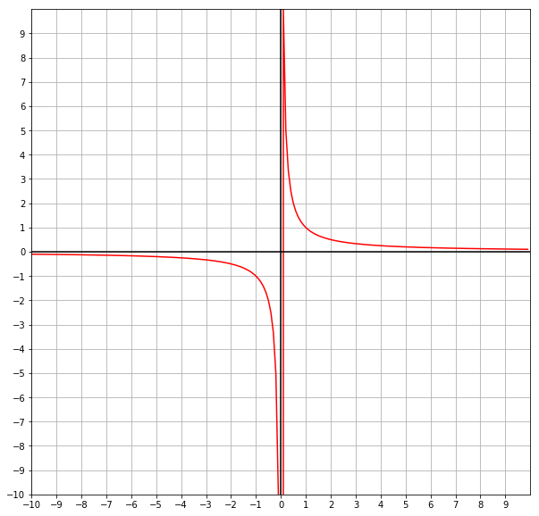

```python
import matplotlib.pyplot as plt
import numpy as np
%matplotlib inline

#plt.rcdefaults()
x = np.arange(-10, 10, .1)

def f1(x):
    answer = 1/x
    return answer

plt.figure(figsize=(10,10))

plt.plot(x, f1(x), c='red')

# optics
plt.axhline(0, color='black')
plt.axvline(0, color='black')
plt.xlim(-10,10)
plt.ylim(-10,10)
plt.xticks(np.arange(-10,10,step=1))
plt.yticks(np.arange(-10,10))
plt.grid(True)


plt.show()
```

45.) $f(x)=\frac{x}{x^2+1}$

(a) $f(0) = \frac{0}{0^2+1} = 0$

(b) $f(1) = \frac{1}{1^2+1} = \frac{1}{2}$

(c) $f(-1) = \frac{-1}{-1^2+1} = -\frac{1}{2}$

(d) $f(-x) = \frac{-x}{-x^2+1} = \frac{-x}{x^2+1}$

(e) $-f(x) = -\frac{x}{x^2+1} = \frac{-x}{x^2+1}$

(f) $f(x+1) = \frac{x+1}{(x+1)^2+1} = \frac{x+1}{x^2+2x+1+1} = \frac{x+1}{x^2+2x+2}$

(g) $f(2x) = \frac{2x}{(2x)^2+1} = \frac{2x}{4x^2+1}$

(h) $f(x+h) = \frac{x+h}{(x+h)^2+1} = \frac{x+h}{x^2+2xh+h^2+1}$

65.) $f(x)=\frac{\sqrt{t-4}}{3t-21}$

Domain = {$t| t \geq 4, t \neq 7$}